# rbiips example: Switching stochastic volatility with estimation of static parameters

In this example, we consider the Markov switching stochastic volatility model with parameter estimation.

Reference: C.M. Carvalho and H.F. Lopes. Simulation-based sequential analysis of Markov switching stochastic volatility models. Computational Statistics and Data analysis (2007) 4526-4542.

# Statistical model

Let $y_t$ be the response variable and $x_t$ the unobserved log-volatility of $y_t$. The stochastic volatility model is defined as follows for $t\leq t_{max}$

$$x_t|(x_{t-1},\alpha,\phi,\sigma,c_t) \sim \mathcal N (\alpha_{c_t} + \phi x_{t-1} , \sigma^2)$$

$$y_t|x_t \sim \mathcal N (0, \exp(x_t))$$

The regime variables $c_t$ follow a two-state Markov process with transition probabilities

$$p_{ij}=Pr(c_t=j|c_{t-1}=i)$$

$$\alpha_1=\gamma_1$$

$$\alpha_2 = \gamma_1+\gamma_2$$

$$\gamma_1 \sim \mathcal N(0,100)$$

$$\gamma_2 \sim \mathcal {TN}_{(0,\infty)}(0,100)$$

$$\phi \sim \mathcal {TN}_{(-1,1)}(0,100)$$

$$\sigma^2 \sim invGamma(2.001,1)$$

$$\pi_{11} \sim Beta(10,1)$$

$$\pi_{22} \sim Beta(10,1)$$

$\mathcal N(m,\sigma^2)$ denotes the normal distribution of mean $m$ and variance $\sigma^2$. $\mathcal {TN}_{(a,b)}(m,\sigma^2)$ denotes the truncated normal distribution of mean $m$ and variance $\sigma^2$.

# Statistical model in BUGS language

Content of the file `'switch_stoch_volatility_param.bug'`:

```r
model_file = 'switch_stoch_volatility_param.bug' # BUGS model filename
cat(readLines(model_file), sep = "\n")
```

```
# Switching Stochastic Volatility Model
# Reference: C.M. Carvalho and H.F. Lopes. Simulation-based sequential analysis of Markov switching
# stochastic volatility models. Computational Statistics and Data analysis (2007) 4526-4542.

var y[t_max],x[t_max],prec_y[t_max],mu[t_max],mu_true[t_max],alpha[2],gamma[2],c[t_max],c_true[t_max],pi[2,2]

data
{
  c_true[1] ~ dcat(pi_true[1,])
  mu_true[1] <- alpha_true[1] * (c_true[1]==1) + alpha_true[2]*(c_true[1]==2)
  x_true[1] ~ dnorm(mu_true[1], 1/sigma_true^2) T(-500,500)
  prec_y_true[1] <- exp(-x_true[1])
  y[1] ~ dnorm(0, prec_y_true[1])
  for (t in 2:t_max)
  {
    c_true[t] ~ dcat(ifelse(c_true[t-1]==1,pi_true[1,],pi_true[2,]))
    mu_true[t] <- alpha_true[1] * (c_true[t]==1) + alpha_true[2] * (c_true[t]==2) + phi_true * x_true[t-1];
    x_true[t] ~ dnorm(mu_true[t], 1/sigma_true^2) T(-500,500)
    prec_y_true[t] <- exp(-x_true[t])
    y[t] ~ dnorm(0, prec_y_true[t])
  }
}

model
{
  gamma[1] ~ dnorm(0, 1/100)
  gamma[2] ~ dnorm(0, 1/100) T(0,)
  alpha[1] <- gamma[1]
  alpha[2] <- gamma[1] + gamma[2]
  phi ~ dnorm(0, 1/100) T(-1,1)
  tau ~ dgamma(2.001, 1)
  sigma <- 1/sqrt(tau)
  pi[1,1] ~ dbeta(10, 1)
  pi[1,2] <- 1 - pi[1,1]
  pi[2,2] ~ dbeta(10, 1)
  pi[2,1] <- 1 - pi[2,2]


  c[1] ~ dcat(pi[1,])
  mu[1] <- alpha[1] * (c[1]==1) + alpha[2] * (c[1]==2)
  x[1] ~ dnorm(mu[1], 1/sigma^2) T(-500,500)
  prec_y[1] <- exp(-x[1])
  y[1] ~ dnorm(0, prec_y[1])
  for (t in 2:t_max)
  {
    c[t] ~ dcat(ifelse(c[t-1]==1, pi[1,], pi[2,]))
    mu[t] <- alpha[1] * (c[t]==1) + alpha[2] * (c[t]==2) + phi * x[t-1]
    x[t] ~ dnorm(mu[t], 1/sigma^2) T(-500,500)
    prec_y[t] <- exp(-x[t])
    y[t] ~ dnorm(0, prec_y[t])
  }
}
```

3. Load rbiips package

```r
require(rbiips)
```

# General settings

```r
par(bty='l')
light_blue = rgb(.7, .7, 1)
light_red = rgb(1, .7, .7)
light_green = rgb(.7, 1, .7)
light_gray = rgb(.9, .9, .9)
```

Set the random numbers generator seed for reproducibility

```r
set.seed(0)
```

# Load model and load or simulate data

```r
sample_data = TRUE # Simulated data or SP500 data
t_max = 100

if (!sample_data) {
  # Load the data
  tab = read.csv('SP500.csv', sep = ";")
  y = diff(log(rev(tab$Close)))
  SP500_date_str = rev(tab$Date[-1])

  ind = 1:t_max
  y = y[ind]
  SP500_date_str = SP500_date_str[ind]

  SP500_date_num = as.Date(SP500_date_str)
}
```

#### Model parameters

```r
if (!sample_data) {
  data = list(t_max=t_max, y=y)
} else {
  sigma_true = .4; alpha_true = c(-2.5, -1); phi_true = .5
  pi11 = .9; pi22 = .9
  pi_true = matrix(c(pi11, 1-pi11, 1-pi22, pi22), nrow = 2, byrow=TRUE)
  data = list(t_max=t_max, sigma_true=sigma_true,
              alpha_true=alpha_true, phi_true=phi_true, pi_true=pi_true)
}
```

#### Compile BUGS model and sample data if simulated data

```r
model = biips_model(model_file, data, sample_data=sample_data)
```

```
* Parsing model in: switch_stoch_volatility_param.bug
* Compiling data graph
  Declaring variables
  Graph size: 1214
  Sampling data
  Reading data back into data table
  Declaring variables
  Graph size: 1232
```

```r
data = model$data()
```

Plot the data

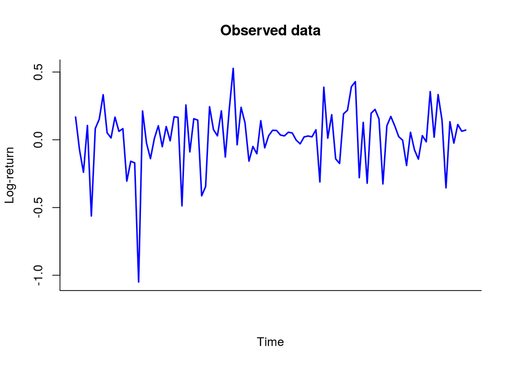

Log-returns

```r
if (sample_data) {
  plot(1:t_max, data$y, type='l', col='blue', lwd=2,
       main='Observed data',
       xlab='Time', ylab='Log-return', xaxt = 'n')
} else {
  plot(SP500_date_num, data$y, type='l', col='blue', lwd=2,
       main='Observed data: S&P 500',
       xlab='Date', ylab='Log-return', xaxt = 'n')
  axis.Date(1, SP500_date_num, format="%Y-%m-%d")
}
```

# Biips Particle Marginal Metropolis-Hastings

We now use Biips to run a Particle Marginal Metropolis-Hastings in order to obtain posterior MCMC samples of the parameters $\alpha$, $\phi$, $\sigma$, $\pi$, and of the variables $x$. Note: We use below a reduced number of MCMC iterations to have reasonable running times. But the obtained samples are obviously very correlated, and the number of iterations should be set to a higher value, and proper convergence tests should be used.

#### Parameters of the PMMH

```r
n_burn = 2000 # nb of burn-in/adaptation iterations
n_iter = 40000 # nb of iterations after burn-in
thin = 10 # thinning of MCMC outputs
n_part = 50 # nb of particles for the SMC
param_names = c('gamma[1]', 'gamma[2]', 'phi', 'tau', 'pi[1,1]', 'pi[2,2]') # names of the variables updated with MCMC (others are updated with SMC)
latent_names = c('x', 'c', 'alpha[1]', 'alpha[2]', 'sigma') # names of the variables updated with SMC and that need to be monitored
```

#### Init PMMH

```r
inits = list(-1, 1, .5, 10, .8, .8)
obj_pmmh = biips_pmmh_init(model, param_names, inits=inits,
                           latent_names=latent_names) # creates a pmmh object
```

```
* Initializing PMMH
```

#### Run PMMH

```r
biips_pmmh_update(obj_pmmh, n_burn, n_part) # adaptation and burn-in iterations
```

```
* Adapting PMMH with 50 particles
  |++++++++++++++++++++++++++++++++++++++++++++++++++| 2000 iterations in 116.00 s
```

```r
out_pmmh = biips_pmmh_samples(obj_pmmh, n_iter, n_part, thin=thin) # samples
```

```
* Generating 4000 PMMH samples with 50 particles
  |**************************************************| 40000 iterations in 2308.50 s
```

#### Some summary statistics

```r
summ_pmmh = biips_summary(out_pmmh, probs=c(.025, .975))
```

#### Compute kernel density estimates

```r
kde_pmmh = biips_density(out_pmmh)
```

#### Compute probability mass function estimates of the discrete marginal variables c[t]

```r
table_c = biips_table(out_pmmh$c)

param_plot = c('alpha[1]', 'alpha[2]', 'phi', 'sigma', 'pi[1,1]', 'pi[2,2]')
param_lab = expression(alpha[1], alpha[2], phi, sigma, pi[11], pi[22])
if (sample_data)
  param_true = c(alpha_true, phi_true, sigma_true, pi11, pi22)
```

#### Posterior mean and credible interval of the parameters

```r
for (k in 1:length(param_plot)) {
  summ_param = summ_pmmh[[param_plot[k]]]
  cat('Posterior mean of ',  param_plot[k], ': ', summ_param$mean, '\n', sep='');
  cat('95% credible interval of ',  param_plot[k], ': [', summ_param$quant[[1]], ', ', summ_param$quant[[2]],']\n', sep='')
}
```

```
Posterior mean of alpha[1]: -3.090382
95% credible interval of alpha[1]: [-5.729467, -0.9685816]
Posterior mean of alpha[2]: -1.987657
95% credible interval of alpha[2]: [-3.794026, -0.5621027]
Posterior mean of phi: 0.3406914
95% credible interval of phi: [-0.2337939, 0.7725778]
Posterior mean of sigma: 0.8450992
95% credible interval of sigma: [0.532169, 1.203331]
Posterior mean of pi[1,1]: 0.8802618
95% credible interval of pi[1,1]: [0.6857646, 0.9970641]
Posterior mean of pi[2,2]: 0.9231584
95% credible interval of pi[2,2]: [0.748389, 0.9945914]
```

#### Trace of MCMC samples of the parameters

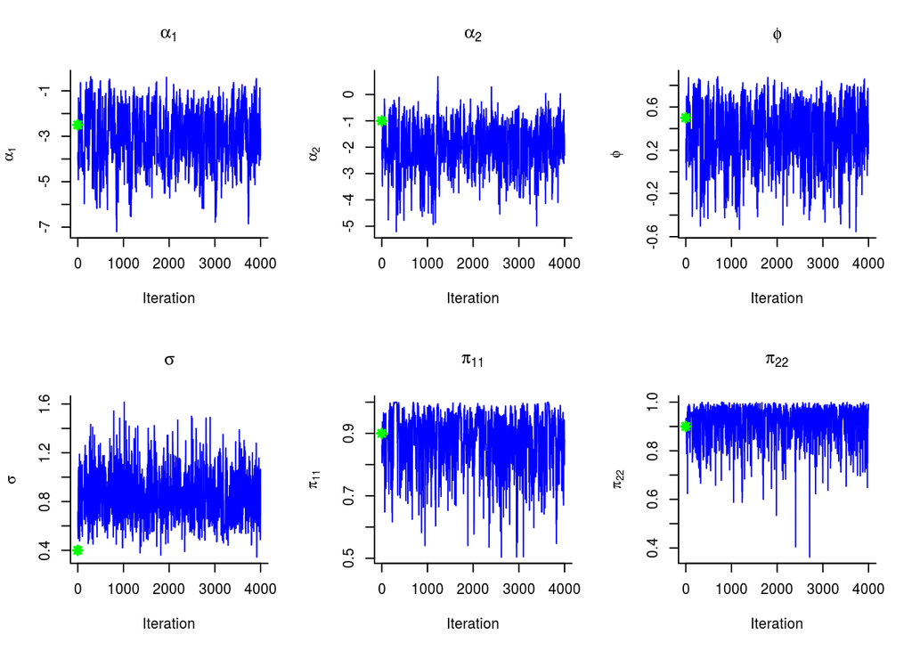

PMMH: Trace samples parameter

```r
for (k in 1:length(param_plot)) {
  samples_param = out_pmmh[[param_plot[k]]]
  plot(samples_param[1,], type='l', col='blue', lwd=1,
       xlab='Iteration', ylab=param_lab[k],
       main=param_lab[k])
  if (sample_data)
    points(0, param_true[k], col='green', pch=8, lwd=2)
}
```

#### Histogram and KDE estimate of the posterior of the parameters

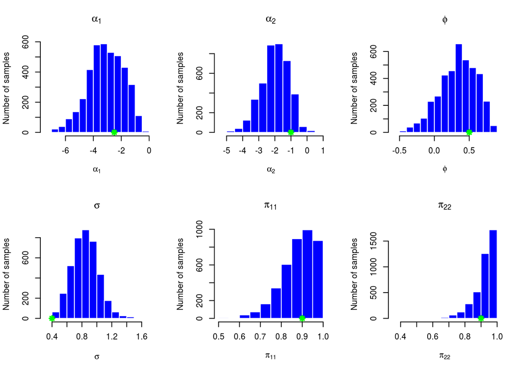

PMMH: Histogram posterior parameter

```r
for (k in 1:length(param_plot)) {
  samples_param = out_pmmh[[param_plot[k]]]
  hist(samples_param, breaks=15, col='blue', border='white',
       xlab=param_lab[k], ylab='Number of samples',
       main=param_lab[k])
  if (sample_data)
    points(param_true[k], 0, col='green', pch=8, lwd=2)
}
```

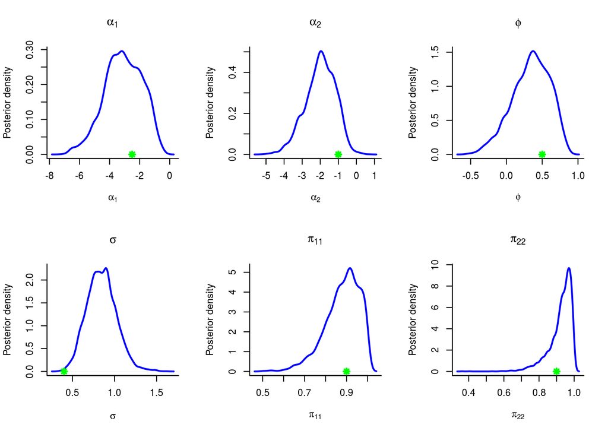

PMMH: KDE estimate posterior parameter

```r
for (k in 1:length(param_plot)) {
  kde_param = kde_pmmh[[param_plot[k]]]
  plot(kde_param, col='blue', lwd=2,
       xlab=param_lab[k], ylab='Posterior density',
       main=param_lab[k])
  if (sample_data)
    points(param_true[k], 0, col='green', pch=8, lwd=2)
}
```

#### Posterior probability of c[t]=2

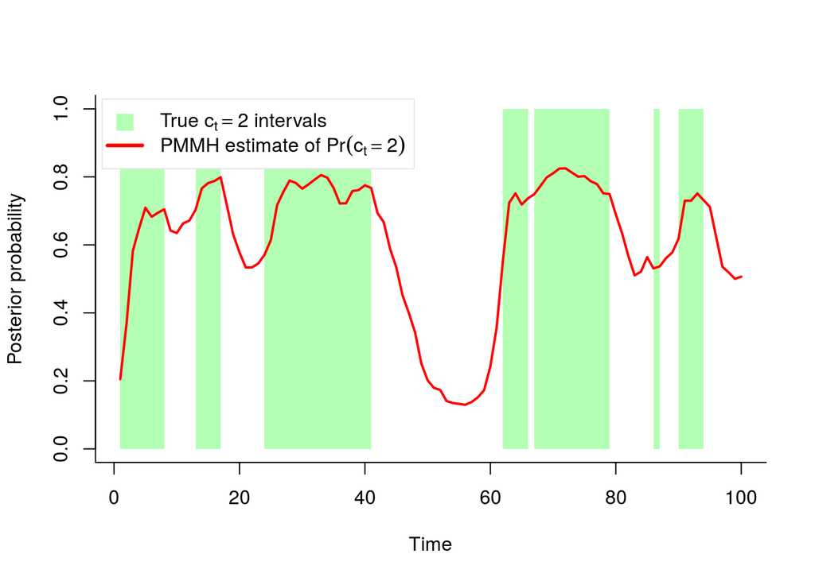

PMMH: Posterior probabilities of c[t]=2

```r
prob_c2 = rep(0, t_max)
plot(1:t_max, rep(1, t_max), type='n', ylim=c(0,1),
     xlab='Time', ylab='Posterior probability')
for (t in 1:t_max) {
  if (data$c_true[t]==2)
    polygon(c(t-1,t,t,t-1), c(0,0,1,1), col=light_green, border=NA)
  ind = which(names(table_c[[t]]) == 2)
  if (length(ind)==0)
    prob_c2[t] = 1-sum(table_c[[t]])
  else
    prob_c2[t] = table_c[[t]][ind]
}
lines(1:t_max, prob_c2, col='red', lwd=2)
legend('topleft', leg=expression(paste('True ', c[t]==2, ' intervals'), paste('PMMH estimate of ', Pr(c[t]==2))),
       col=c(light_green, 'red'), lwd=c(NA,3), pch=c(15,NA), pt.cex=c(2,1),
       box.col=light_gray, inset=.01)
```

#### Posterior mean and quantiles for x

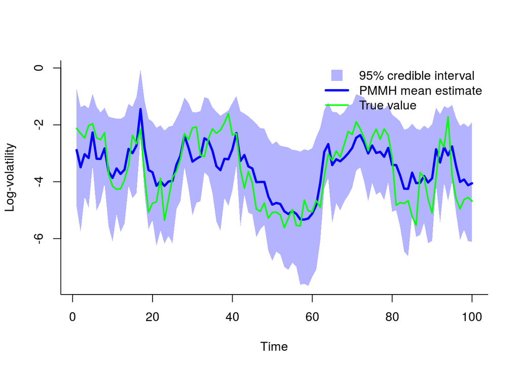

PMMH: Posterior mean and quantiles

```r
x_pmmh_mean = summ_pmmh$x$mean
x_pmmh_quant = summ_pmmh$x$quant

xx = c(1:t_max, t_max:1)
yy = c(x_pmmh_quant[[1]], rev(x_pmmh_quant[[2]]))
plot(xx, yy, type='n', xlab='Time', ylab='Log-volatility')

polygon(xx, yy, col=light_blue, border=NA)
lines(1:t_max, x_pmmh_mean, col='blue', lwd=3)
if (sample_data) {
  lines(1:t_max, data$x_true, col='green', lwd=2)
  legend('topright', leg=c('95% credible interval', 'PMMH mean estimate', 'True value'),
         col=c(light_blue,'blue','green'), lwd=c(NA,3,2), pch=c(15,NA,NA), pt.cex=c(2,1,1),
         bty='n')
} else
  legend('topright', leg=c('95% credible interval', 'PMMH mean estimate'),
         col=c(light_blue,'blue'), lwd=c(NA,3), pch=c(15,NA), pt.cex=c(2,1),
         bty='n')
```

#### Trace of MCMC samples for x

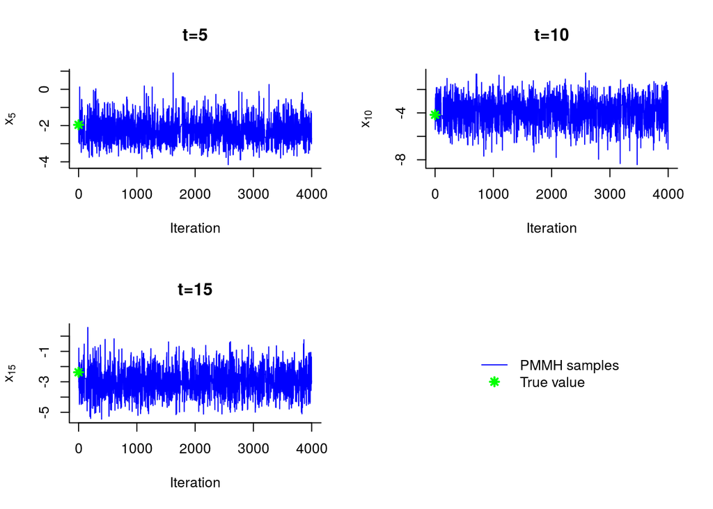

PMMH: Trace samples x

```r
time_index = c(5, 10, 15)
par(mfrow=c(2,2))
for (k in 1:length(time_index)) {
  tk = time_index[k]
  plot(c(out_pmmh$x[tk,]), col='blue', type='l',
       xlab='Iteration',
       ylab=bquote(x[.(tk)]),
       main=paste('t=', tk, sep=''))
  if (sample_data)
    points(0, data$x_true[tk], col='green', pch=8, lwd=2)
}
if (sample_data) {
  plot(0, type='n', bty='n', xaxt='n', yaxt='n', xlab="", ylab="")
  legend('center', leg=c('PMMH samples', 'True value'),
         col=c('blue', 'green'), pch=c(NA,8), lty=c(1,NA), lwd=c(1,2),
         bty='n')
}

par(mfrow=c(1,1))
```

#### Histogram and kernel density estimate of posteriors of x

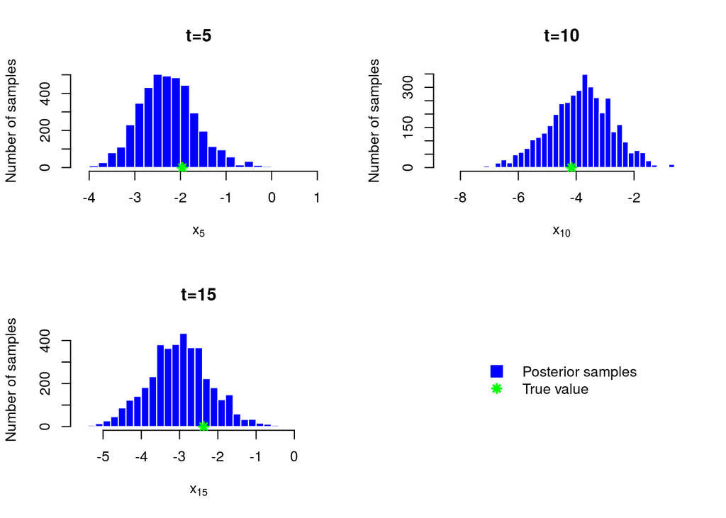

PMMH: Histograms marginal posteriors

```r
par(mfrow=c(2,2))
for (k in 1:length(time_index)) {
  tk = time_index[k]
  hist(out_pmmh$x[tk,], breaks=30, col='blue', border='white',
       xlab=bquote(x[.(tk)]),
       ylab='Number of samples',
       main=paste('t=', tk, sep=''))
  if (sample_data)
    points(data$x_true[tk], 0, col='green', pch=8, lwd=2)
}
if (sample_data) {
  plot(0, type='n', bty='n', xaxt='n', yaxt='n', xlab="", ylab="")
  legend('center', leg=c('Posterior samples', 'True value'),
         col=c('blue', 'green'), pch=c(22,8), lwd=c(1,2), lty=NA, pt.cex=c(2,1), pt.bg=c(4,NA),
         bty='n')

}
par(mfrow=c(1,1))
```

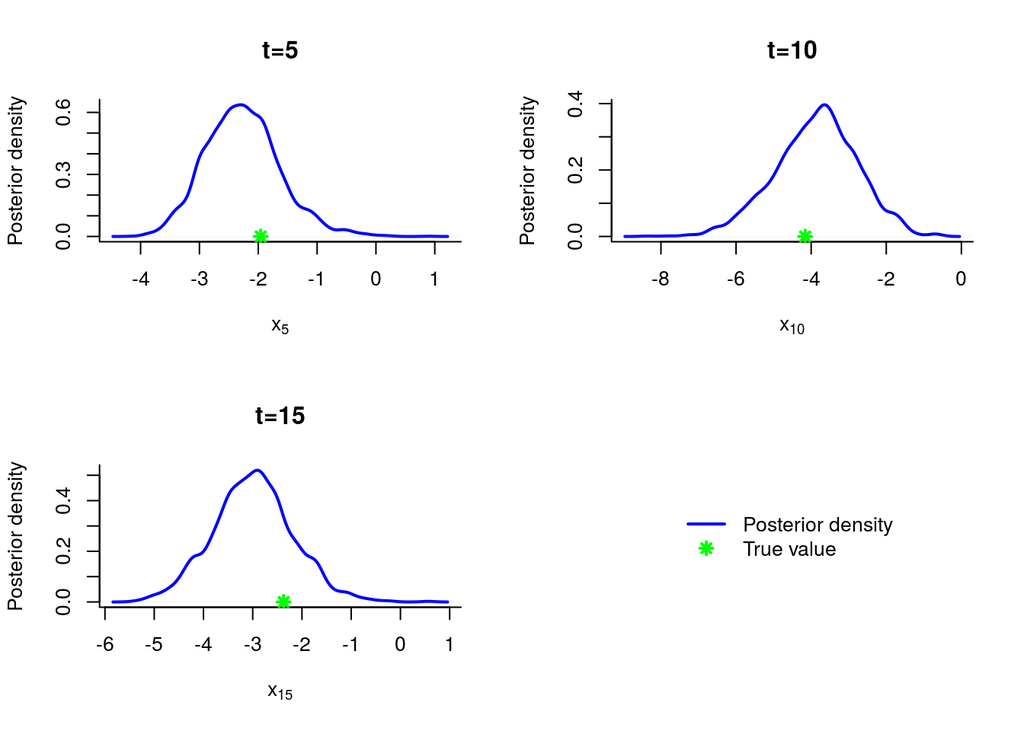

PMMH: KDE estimates marginal posteriors

```r
par(mfrow=c(2,2))
for (k in 1:length(time_index)) {
  tk = time_index[k]
  plot(kde_pmmh$x[[tk]], col='blue', lwd=2,
       xlab=bquote(x[.(tk)]),
       ylab='Posterior density',
       main=paste('t=', tk, sep=''))
  if (sample_data)
    points(data$x_true[tk], 0, col='green', pch=8, lwd=2)
}
if (sample_data) {
  plot(0, type='n', bty='n', xaxt='n', yaxt='n', xlab="", ylab="")
  legend('center', leg=c('Posterior density', 'True value'),
         col=c('blue', 'green'), pch=c(NA,8), lwd=2, lty=c(1,NA), pt.cex=c(2,1), pt.bg=c(4,NA),
         bty='n')
}
par(mfrow=c(1,1))
```